# Racial Bias in Facial Detection and Recognition Systems

## Abstract

The LFW, FERET, and Fairface databases were examined for racial bias. Openface and OpenCV were used to create the neural networks evaluated for bias. All models showed some degree of racial discrepancy, but Fairface’s discrepancy was in the range of normal error. The same cannot be said for the models built from LFW and FERET. While Fairface (a pointedly diverse data set) did not show the same signs of racial bias of the other datasets, insufficient evidence was found to suggest this is due to diversity alone. Futhermore, it was shown that this accuracy disparity was not due to the amount of light available in an image alone. In addition, several sampling techniques were tested as method to mitigate this bias. Insufficient evidence was found to say that sampling techniques alone can mitigate this bias. Plenty of weak evidence was found to suggest that racial bias in facial recognition systems was due to a lack of diversity in the training data. However, further research is required for a strong, positive confirmation.

## Introduction

Predictive policing is already a policy that is fully in place. The Compas Algorithm(Yong 2018) is used to predict recidivism in arrested individuals and has had questionable efficacy (Dressel and Farid 2018). The Brookings Institute (Turner-Lee, Resnick, and Barton 2019) has outlined many cases in which racism and sexism were unintentionally built in to models through several means, including labeling bias, sampling bias, and even the composition of the teams in involved. Amazon’s Rekognition (“Amazon Rekognition Video and Image - AWS” 2019) platform active pursuit of a contract with Immigration and Customs Enforcement. In the Summer of 2019, a teen was falsely arrested and sued Apple for it’s alleged use of facial recognition technology (Liao 2019), escalating this technology to Minority-Report levels of use, without corresponding checks on its efficacy or bias. Finding the relationship between data, models, and racial bias is critically important in 2019. In particular, it is necessary to measure various techniques used in the wild (OpenCV, Keras), see if they carry the bias discussed in “Predictive Analytics in Object Detection” (2019a)

Methods to mitigate bias:

The “Partnership on AI” has written a “Report on Algorithmic Risk Assessment Tools in the Criminal Justice System” that broke down the ways in which models can carry human bias:

1. Equal opportunity failures: equal false positive/negative rates across protected classes like race and gender. For the case of human detection algorithms, false negatives are the priority since we don’t want cars to hit dark-skinned people. For facial-recognition systems, we could aim for class parity across false-positive rates so that all classes are misidentified equally. However, that means that each class will have a distinct accuracy score (often measured by f1 score, or a combined metric of both false positive and false negative rates).
2. Predictive parity: The second method optimizes for parity across f1 scores for various classes. This is known as calibration within groups. This will, as explained above, lead to differences in the model’s failure rate when isolated to the metrics discussed above.
3. The third approach is to build causal models and eliminate any confounding correlation as it “formally addresses the difference between correlation and causation and clarifies the causal assumptions underlying the model”. This does not mean that models with complex input/output characteristics need to be discarded, just that the sensitivity of the model to each component and each input characteristic needs to be examined. In addition, particular subject matter expertise is required to understand the root cause of correlation between measured variables.

The first two approaches are outside the scope of this paper because they merely re-frame the bias problem as a disparity between accuracy or precision, but do nothing to explain why that happens. In order to investigate the root causes, this paper attempts to address method three. Despite that attempt, there are some limitations to this research. Name to due cost and time restrictions, it is prohibitively expensive to build many models on the given datasets. This paper does employ cross-validation to ensure that random partitions of the data do not misinform the analysis, but time restrictions limited the tested parameters to dataset, foreground (i.e. skin-tone) luminance, and race (in the case of Fairface). Further causal relationships could be examined by controlling for sample size, controlling for the number of images per class, or evaluating a trade-off between comparmentalized accuracy/precision scores and the model bias shown between them. See the “Further Work” section for more information.

### Hypothesis

Since the models are ambivalent mathematical machines, the bias comes from the input data and the choice of pre-processing methods. To that end, we will explore three datasets and several subsetting methods.

1. With a strictly randomized data set, which facial recognition model, if any, will carry the most racial bias?
2. Does this happen when we stratify the data or apply other resampling techniques?
3. Can we reproduce this effect across the entirety of the FERET set since it is influenced by racial and gender sampling biases.

Due to myriad prior research on racial bias in these systems and the pitfalls of biased sampling, it is suspected that we will be able to reproduce racial discrepancies in our biased datasets.

These biases are inherent to model-making and statisticians have identified several sources of uncertainty(“Report on Algorithmic Risk Assessment Tools in the U.S. Criminal Justice System - The Partnership on AI” 2019). The foremost issue to data scientists is the uncertainty due to sampling and the presence of outliers either in the data or in the real world, which is easily measured by bootstrapping the samples (i.e. sampling with replacement). This allows us to get a confidence interval for each bootstrapped class. Uncertainty, expressed as confidence intervals, is often used to highlight the range of reasonable model outputs. For classification problems, however, the model itself doesn’t give a confidence interval, so we must run many variations of the model to predict the stability of the accuracy. This can be accomplished through subsetting or testing the models across a variety of suitable hyper-parameters. Due to to the time restrictions mentioned above, this analysis was limited to k-fold cross validation, ensuring that every image was tested exactly once for each model.

#### Hypothesis 1

$$H_0: \text{ There is insufficient evidence to suggest there is a discrepancy in accuracy for person detection or recognition algorithms }$$

$$H_a: \text{ There is sufficient evidence to suggest there is a discrepancy in accuracy for person detection or recognition algorithms }$$

#### Hypothesis 2

Furthermore, using image analysis techniques, we can calculate the luminance of each image and determine it’s correlation to model accuracy.

$$H_0: \text{ There is insufficient evidence to suggest model discrepancy is due to anything other than the amount of light available in an image}$$
$$H_a: \text{ There is sufficient evidence to suggest model discrepancy is due to something other than the amount of light available in an image}$$

#### Hypothesis 3

Very recently, researchers (Kimmo and Joo 2019) have made available a dataset (joojs 2019) that has a much more diverse photograph catalogue than other facial recognition systems. Their paper includes the following image

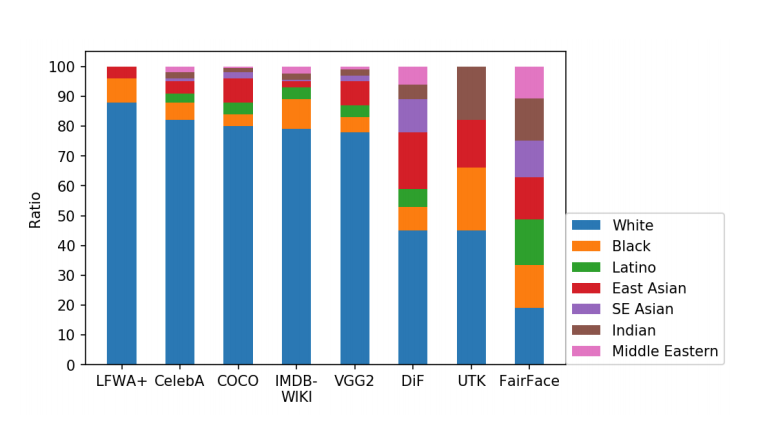

They also claim that their data leads to less biased results. That will also be tested.

$$H_0: \text{ There is insufficient evidence to suggest model discrepancy can be alleviated by using a more diverse sample space}$$

$$H_a: \text{ There is insufficient evidence to suggest model discrepancy can be alleviated by using a more diverse sample space}$$

#### Hypothesis 4

In addition, there is prior research (Mahabadi 2019) suggesting the benefits of balanced sampling or stratified sampling when building classification models. This is also testable with the data and models proposed

$$H_0 : \text{ There is insufficient evidence to suggest that different sampling methods will alter this racial bias indicator}$$

$$H_0 : \text{ There is sufficient evidence to suggest that different sampling methods will alter this racial bias indicator}$$

### Data:

I will use the FERET dataset to build the models since it is well-documented, well-tested and one of the de-facto standards for pose, gender, and racial differences in datasets. Additionally, I have a copy of the [Microsoft Celebrity Dataset](https://www.vice.com/en_us/article/a3x4mp/microsoft-deleted-a-facial-recognition-database-but-its-not-dead) for final model evaluation since the data is far more raw than the FERET dataset of well-illuminated, standardized pictures of hundreds of people over time. It also contains 11 thousand images of 984 people, which should be sufficient to testing bias of these algorithms. I will also use the LFW dataset (“LFW Face Database : Main” 2019), which contains 13 thousand images of celebrities and the Fairface (Kimmo and Joo 2019) dataset which contains a purposefully diverse set of 80 thousand people each photographed once, complete with crowd-sourced racial data.

### Models

I will investigate the OpenCV and Openface person detection systems as well as variod neural network models compatible with these toolchains.

### Testing Methods:

Re sampling can be done by many different methods (Kummerfeld and Rix 2019). Bootstrapping comes in the random forest, balanced, and stratified varieties. All will be tested. Cross-validation ensures that many random partitions of the data are tested independently of each other. Hyper parameter tuning can effect a model’s performance, especially if we optimize for each type of model differently. Therefore, each model will run as a stand-alone Python application that processes a pre-selected dataset, self-tunes its parameters, and reports the results to a central driver. The sampling will occur in this central application so that every model can be tested against the same subsets.

## Modelling Methods

### Skin Tone Estimation

The Fitzpatrick skin phototype is a six-point scale for measuring response to ultra-violet radiation. It ranges from “Deeply pigmented” to “pale white” in describing skin and its response to sunlight (Del Bino and Bernerd 2013). It, however, relies on eye-color and self-reported data that are not available in any facial-recognition data set. However, the Fitzpatrick scale reflects the very-real phenomenon of how light interacts with different skin types. Since images deal with the visible spectrum, we can measure the intensity of light that is reflected off of the skin. This is the primary measure of concern because cameras, radars, and LIDARs will pilot autonomous vehicles and be widely used in the surveillance and security industry. In effect, luminance can map skin color to the physical phenomenon that would hinder the efficacy of a person-detection technology in an autonomous vehicle or, more commonly, the automatic soap dispenser in a restroom. I introduce a caveat here in that different skin types respond to different frequencies of light differently, but large data sets with wide-spectrum photographs do not seem to exist at the time of writing.

### How Colors Work

Colors are stored in images in many ways. The most common way is as an x-y grid where each cell contains the color value, stored as a third dimension. Most of the time this has a 1 byte depth for each of blue, green, and red values, meaning each cell contains color information for 256 values of red, green, and blue or, one of 16 million possible colors.

#### Gray Scale

The ITU-R BT.709 Standard (“RGB to grayscale — skimage v0.17.dev0 docs” 2019) was developed for this as a more bandwidth-efficient way to encode color data, since humans are more sensitive to luminosity in general than any color in particular. This is the standard that modern computers use to turn color images into grey scale ones.

$$Y = .2125r + .7154 g + .0721 b$$

### OTSU Binarization and Thresholding

Otsu’s method for foreground/background separation is well-documented(“3.3.9.7. Otsu thresholding — Scipy lecture notes” 2019) as a good solution to the problem of finding the foreground of an image. It does this by exhaustively finding the inter- and intra-class variance across all possible bifurcations such that it minimizes the former and maximizes the latter. The optimization function can be seen below.

$$\sigma^2_w(t) = w_0(t) \sigma_0^2(t) + w_1(t) \sigma_1^2(t)$$

where $\sigma$ is the variance, $t$ is the characterization, and w is the respective weight of the two classes (foreground and background). In our algorithm, the threshold step is used to collect the largest such cluster of points that meet certain color requirements discussed below. The class probability is calculated exhaustively from $L$ bins such that

$$w_x(t) = \sum_{i=0}^{L-1}p(i)$$
where $i$ is inter class variance. Because it searches all possible parameterizations, this method is complete and is guaranteed to find and optimal solution. Thresholding, however, is approximate and is a source of potential error, particularly for people with extreme values of red, green, or blue in their complexion.

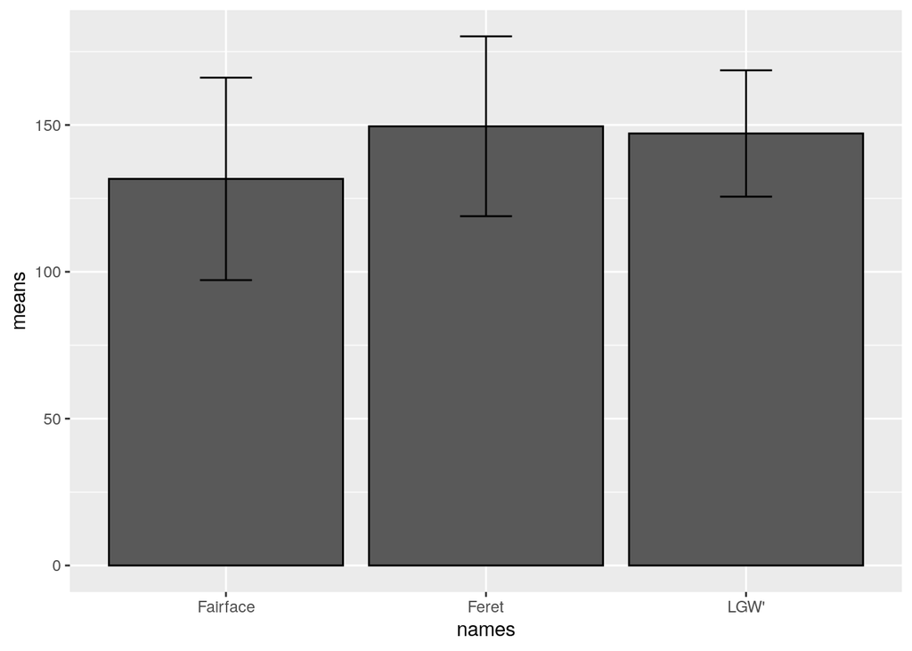

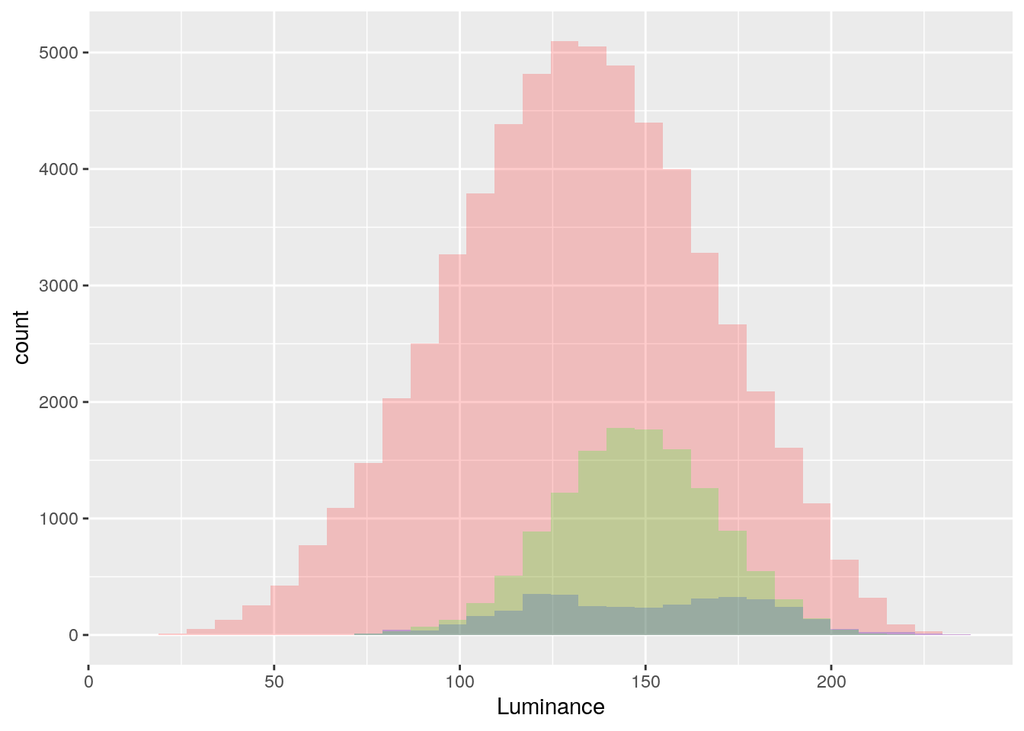

If we accept that the much larger Fairface dataset more accurately represents the mean human, then the other datasets are significantly lighter than Fairface and draw from a substantially smaller portion of the human skin-tone spectrum, particularly with luminance values less than one hundred.

#### HSV, YCrCb

In addition to the red, green, and blue, and grey-scale color spaces, there are two more. The first is the Hue-Saturation-Value model which is a radial model where hue and saturation encodes a single color while hue contains the intensity. It is used to help [separate colors](https://answers.opencv.org/question/39080/pros-cons-between-hsv-and-ycbcr-in-image-segmentation/) in an image whereas the other model (YCrCb) is better at segmenting out intensity variations. This model also stores a photograph as three numbers per cell: luminance, geometric distance from red, and geometric distance from blue. In effect, it encodes color as a difference in luminance and is tied closely to the standard mentioned above. These methods allow us to cluster skin patches that can vary in brightness and color, but less so than the surrounding areas. The skin-tone detection process uses all three spaces and only measures the pixels that are common among all three, increasing the confidence in the particular choice of pixels.

## The Genetics of Skin Color

The scientific relationship between skin color and light reflectivity is well established. In fact, the ability to reflect light is why light skin evolved (Barsh 2003). “Credit for describing the relationship between latitude and skin color in modern humans is usually ascribed to an Italian geographer, Renato Basutti, whose widely reproduced “skin color maps” illustrate the correlation of darker skin with equatorial proximity (Figure 2). More recent studies by physical anthropologists have substantiated and extended these observations; a recent review and analysis of data from more than 100 populations (Relethford 1997) found that skin reflectance is lowest at the equator, then gradually increases, about 8% per 10° of latitude in the Northern Hemisphere and about 4% per 10° of latitude in the Southern Hemisphere. This pattern is inversely correlated with levels of UV irradiation, which are greater in the Southern than in the Northern Hemisphere."

## Data Schema:

The data is available online from eacj respective dataset source. The only transformation I did prior to the described analysis is using the `tar` utility to unzip the folders. Check sums were verified to assure data integrity. Each model will process the data in series to avoid race conditions, or in parallel when there are multi-partite sets. The biggest factor in model testing will be the I/O speed from the database to the disk. Since I’m not allowed to share the FERET dataset, I’ve decided to treat the entire set as a folder mounted inside the repository in the ‘data/’ directory so that the reader can reproduce the research with the FERET dataset or any other that follows the same folder structure. Further information is available in the source code documentation.

## Models:

Each of the above questions are falsifiable and testable. The underlying assumption is well-documented, but must still be shown for the dataset in question. The dataset will be tested against each of the below models which will run as stand-alone applications that self-tune and report data back to a central database.

### Classical Methods

Historically, many ‘classical’ matrix decomposition techniques have been used for image classification tasks. Those methods include singular vector decomposition (using either the left or right handed vectors as features) or linear discriminant analysis.

In general, object detection systems must extract features from images before using those features to classify them. There are many ‘classical’ ways to derive those features and examining them will give us a conceptual framework for the neural networks evaluated later.

#### Eigenfaces

Because images are usually represented as matrices with several color channels (dimension), it is convenient to do traditional matrix decomposition techniques on them to extract features and reduce dimensionality (Turk 1991). That is, we can use the eigenvectors as an approximator for an image such that the eigenvectors are given by

$$S = AA^Tv_i = \lambda_iv_i$$

where $S$ is the covariance matrix, T is the data matrix, and lambda is the eigenvalue. If the number of samples is smaller than the input rank, then we can use

$$S = A^TAv_i = \lambda_iv_i$$
instead.

### Independent Component Analysis

(Bartlett 2002)

Independent component analysis can be thought of as a generalized version of principal component analysis above in that it guarantees statistical independence in the components. If we say that

$$x = As$$
where $x$ is the matrix of observed mixtures, $s$ is the vector of source signals, and $A$ is the set of components that comprise the model. In general, it is calculated by finding an unmixing matrix $W$ such that

$$u = Wx = WAs$$

and $u$ is defined by the condition that entropy is maximized when independence is maximized, defined as

$$H(u) = -\int f_u(u)du$$

#### Fisherfaces

Fisher’s detection algorithm follows the same pattern (Etemad and Chellappa 1997). An image matrix, $X$ is constructed from images. Using PCA, we project the image vector onto a lower-dimensional subspace of dimension $N$ by $c$, or number of samples and number of classes respectively. From here, we seek to maximize the distance between classes $B$

$$B = \sum_{i=1}^{c} N_i(\mu_i - \mu)(\mu_i - \mu)^T$$

while minimizing the value of $W$, the distance within a given class.

$$W = \sum_{i=1}^{c} \sum_{x_k \in X_i} (x_k - \mu_i) (x_k - \mu_i)^T$$

In particular, the Fisher algorithm uses Linear Discriminant Analysis to find $W$ and $B$. It is both a conceptual and historical bridge to modern techniques that combine multiple models for extracting features, before classifying them according to those features using a different model. The next several models are pre-trained and are components in identityfing faces in even more advanced models.

### Viola Jones Algorithm

The Viola-Jones detection algorithms are very import for real-time object detection as they consist of pre-trained features that exploit local binary histograms, or two-dimensional features spaces in order to detect a human. Those features look like the images below (Viola and Jones 2001) Where A vertical lines, B detects horizontal lines, c detects edges, and d detects diagonal lines. These individual detectors applied to each image in succession, arranged by predictive power. In this way, the filters act as a cascade that is able to quickly reject things that do not appear to be human.

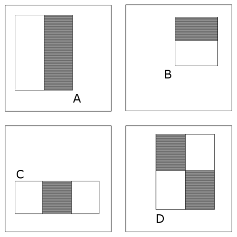

[figure not shown]

The filters come in various sizes and scale with the image that are chosen during the training process. Like images, they can be represented mathematically as matrices such that a top-left to bottom-right three by three matrix filter would look like

$$\begin{bmatrix}
1 & 0 & 0 \\
0 & 1 & 0 \\
0 & 0 & 1
\end{bmatrix}$$
when represented by single bits. Likewise, a nine-pixel, 3 byte luminance, horizontal filter would like like

$$\begin{bmatrix}
0 & 0 & 0 \\
255 & 255 & 255 \\
0 & 0 & 0
\end{bmatrix}
\text{ or }
\begin{bmatrix}
255 & 255 & 255 \\
0 & 0 & 0 \\
255 & 255 & 255
\end{bmatrix}$$
Later, we will see how neural networks approximate these matrices with ‘networks’ of learned weights that take the form of numerical matrices that act on the data. The matrices are much larger, with a single model having hundreds of thousands or millions of parameters. Haar cascades, however, are streamlined via boosting, as we see below.

#### Haar Cascades

Haar cascades are relatively strong models built on applying many subsequent weak classifiers of the form

$$h(x) = sgn(\sum_{j=1}^Xa_jh_j(x))$$

where $h_j(x)$ is a weak classifier like the ones pictured above. Each one is weighted by some weight, $alpha$, and each is passed through a signum operator that binarizes the output to either positive one or negative one, ‘yes’ or ‘no’. The $a$ value is iteratively set inversely proportional to the error rate during the learning algorithm, until the accuracy of $h(x)$ is maximized. In general, this model construction technique is known as Boosting and has wide application to both regression and classification problems. However, each cascade is heavily dependent on pose, with each library providing several models for each front-facing and profile photographs. [OpenCV](https://github.com/opencv/opencv)

#### Kalman Filtering

While outside the scope of this project because it requires time-series data, it’s important to note how model inaccuracies effect real-time systems. Kalman filtering is a mathematical model wherein a Monte-Carlo method is applied to time series datasets. For example, an autonomous vehicle collects 3 dimensional point clouds which it must conceptualize in order to navigate. This conceptualization process involves either pre-trained neural networks or binary pattern histograms (like Viola Jones). A few missed frames of object detection in such a tracking system could lead to wildly inaccurate estimations in the point-cloud models that only get worse with subsequent failures in the detection system. For these reasons, many autonomous vehicle manufacturers have turned to neural networks for image processing for their superior generalization and ability to be pre-trained.

### Face Recognition using CNN

Deep neural networks create networks of these weight matrices, in various layers, that approximate functions like the ones discussed above. They have been shown to be superior to the techniques discussed above, at the cost of an greatly extended training time and larger model size.

A ‘neuron’ in a neural network is a function on a set of weights. In our case, we will use the smooth RELU function that has been shown to perform well.

$$f(x) = log(1+e^x)$$
where x is the input data. Each of these neurons help to extract local features that are combined into higher dimensional feature spaces by using pooling and convolution layers that form the aforementioned ‘networks’. (Liu and Deng 2015)

Convolution is a common signal processing technique, typical for transferring from one domain to another. In signal processing it is used to conduct Fourier Analysis which converts from a noisy time domain to a more stable frequency domain. In our case, it is used as a way to weight pixels against other pixels and get a mathematical sense of ‘texture’.

$$f \circledast g = \sum_{m=-\infty}^{\infty} f(m)g(m-n)$$

Each image will ‘feed-forward’ through a network

In this paper I investigated the algorithms underlying opensource face recognition and detection tooling. In particular, I am looking at the tooling behind OpenCV (opencv 2019) and Openface (Mellon 2019) which have each been forked by thousands of developers.

#### OpenCV

The architecture that OpenCV uses relies on C++ libraries called dlib that perform the underlying calculations for image recognition. It was submitted to a 2014 competition called ILSVRC and scored 92.7% on a generic object recognition task. (“ImageNet Large Scale Visual Recognition Competition 2014 (ILSVRC2014)” 2019). According to the authors of the original paper, it took weeks to train on a fleet of high-end, expensive GPUs (Simonyan and Zisserman 2014). Unfortunately, this paper did not rely on tens of thousands of dollars worth of GPUs.

The OpenCV model was trained on ImageNet(“ImageNet” 2019), which is a database of 15 million images with 22 thousand labelled classes. It has shown to be a reliable dataset for image classification tasks, with hundreds of citations spanning a decade. The Dlib implementation benefits from pre-trained weights which make computation faster, but not fast by any means.

In general, these networks are comprised of pooling and convolutional layers that compress or filter the image respectively. Specific architectures are highly arbitrary and subject to constant contest and academic advancement. However, VGG is widely implemented via the dlib library and it’s network architecture can be pictured below

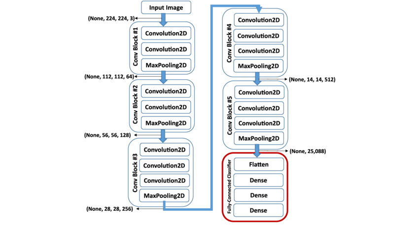

(Gopalakrishnan et al. 2017)

A pre-trained dlib face detector was used to classify each of the image sets. Using a the pre-determined network above, we found a set of weights that correspond to each image, known as embeddings, that are a cascade of matrices that correspond to high-dimensional transformations that map an input to something that is separable by a clustering algorithm or support vector machine.

#### Openface

Rather than just models, Openface provides an entire toolchain for building and classifying images. For this research, both detection and recognition accuracy improved greatly when Openface’s “deep-funneling” technique was used on the training data. Much like the dlib libraries, it uses a generic Haar-cascade to detect images. For the sake of standardization in my evaluation, I used IBM’s frontal default classifier available in the OpenCV repository. Since only the FERET database included profile data, only the front facing images were evaluated. Openface’s algorithm, in addition to detection, is able to find facial landmarks and rotate, scale, and center the faces using a neural network, producing a final, ‘cropped’ image.

[figure not shown]

(Mellon 2019)

These images are fed into a neural network that generates a set of embeddings of each input image that serve as a compressed version of the image. These are then fed into a clustering or other classification algorithm. In my small scale experiments, clustering algorithms had the best trade-off between speed and accuracy since they have a smaller searchable parameter space in sci-kit learn’s implementation.

## Data Pipeline

In order to process mountains of data across the various models, a data pipeline was created. First, each image was processed for the luminance value of the object in the foreground. Since this did not use a cascade classifier, it was applied to every image. Next the IBM frontal face cascade was used to detect each image before being passed to OpenFace’s alignment and cropping algorithm (nn4). That data was then handed to opencv for model training, which generates a csv of embeddings and (true) labels for each input image. That was then handed to a sci-kit learn application that built a k-fold model across the entire dataset. Due to time constraints, only the k-nearest-neighbors model was tested at scale. To test the generalization ability of each model with the limitation of being able to only identify people trained in each model, the final model was tested against the original (uncropped, unaligned data) for each dataset. While this method may not produce models with the most generalizability, it gives an accurate picture of a models ‘best-chance’ predictions across a large dataset, and, strictly speaking, the unprocessed images are novel input for the algorithm. In addition, due to the high failure rate of the detection cascades, the training data was only about 40% of the input sample size. A classification report was generated for each model. This all occurred in the cloud in a series of docker-containers that allowed for maximum code portability, fast processing times, and the management of competing software library dependencies.

## Analysis

### Detection Breakdown

Because each processing technique created a new file, I was able to quickly calculate how many images passed each detector using shell commands like `find` and `wc`. However, because the data includes images known to influence the classifier (like people with beards, glasses, and hats), a racial analysis was not done because there’s no way to parse the racial failures from the known expected failures.

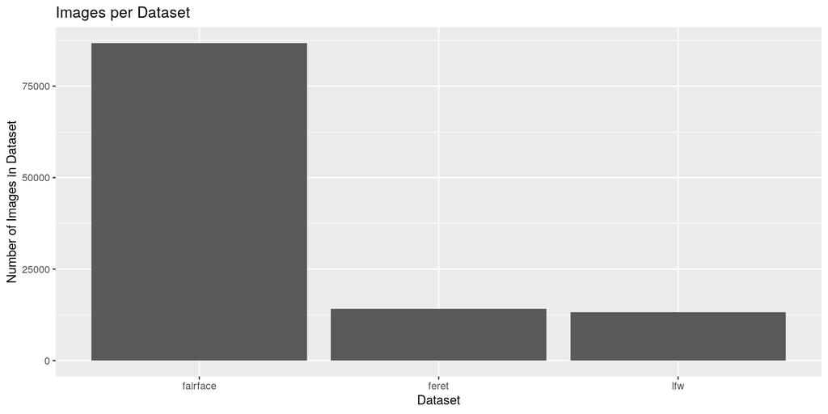

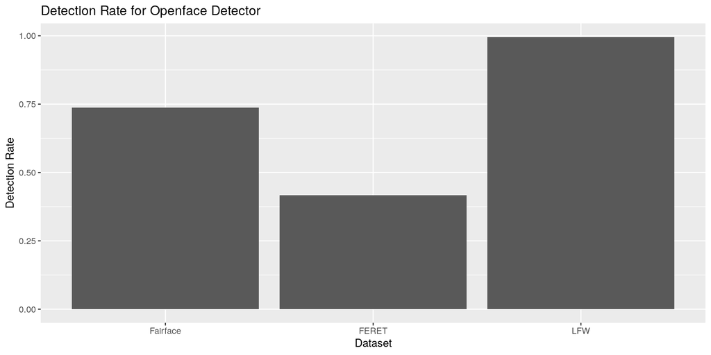

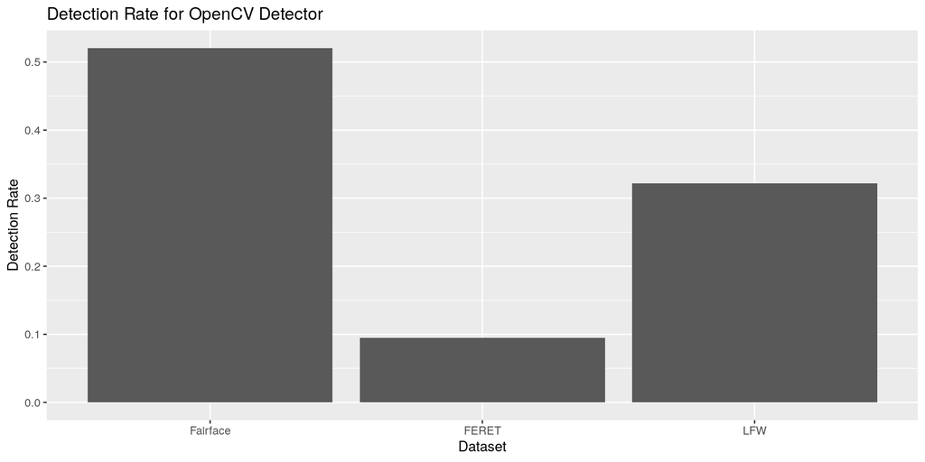

### Dataset Analysis

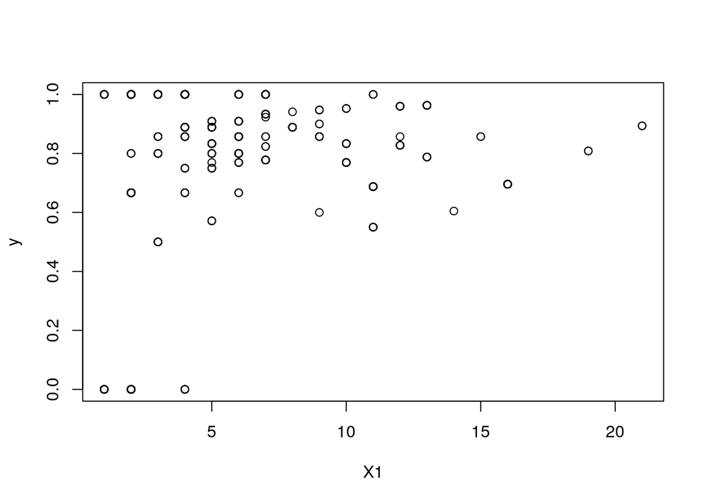

With a correlation value of .11, it seems as if accuracy of the model on a given image is only partially related to the sample space of that class.

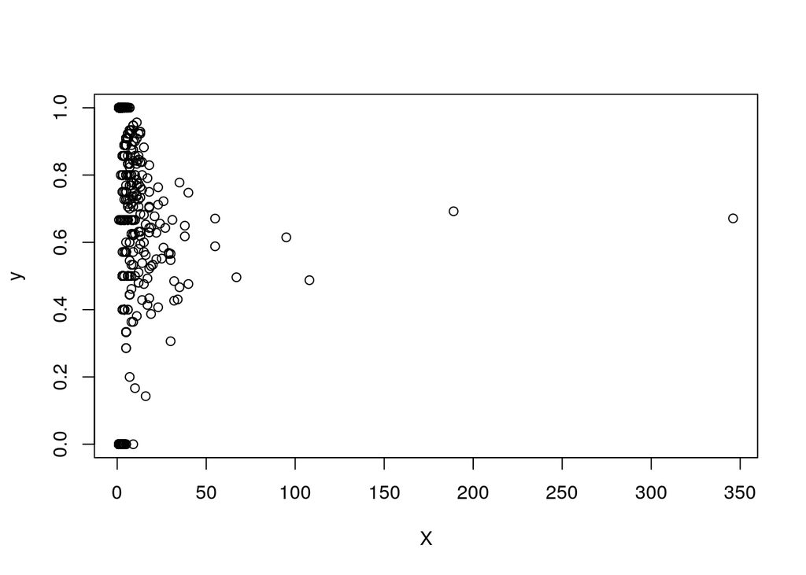

With a correlation score of .05, this is even more clear on the LFW dataset. As we can see, most classes have less than fifty samples, but a few classes have much more. Even with the wide sample size spectrum, we see little correlation between support and accuracy.

The Fairface dataset is composed of a single image per identity for 90 thousand identities. Additional race and gender data is provided. So, the only recognizer I could test is a gender recognizer (since you need more than 1 image of a person to test/train a model). Results from that test are addressed in the next section.

### Bias Comparison

For most of the data, we were note provided with racial data, so the automated process discussed above was used. For the sake of this analysis, the data was binned into three equally spaced (though not equally sized) categories and a separate score analysis was applied to each category. Below, we can see the average accuracy for each dataset.

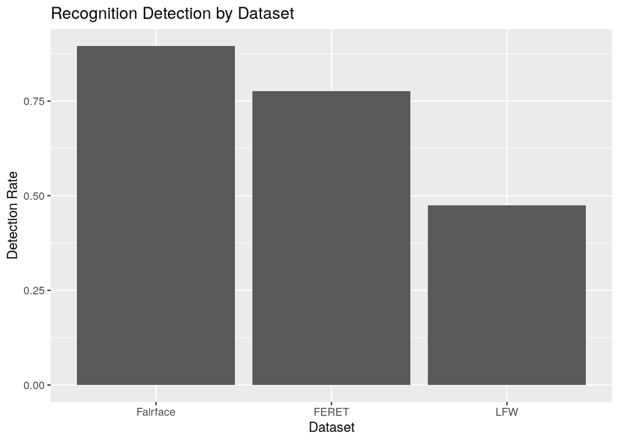

$$\text{gap score} = \bigg(\frac{P(Y|A=j)}{P(Y|A = k)}\bigg)$$
as suggested by the Fairface researchers (2019b).

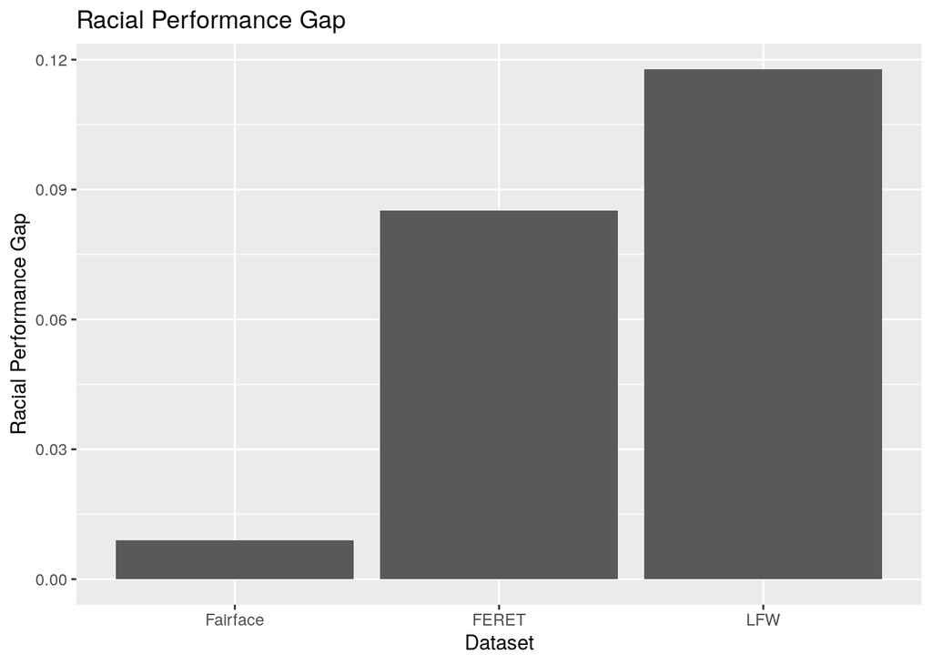

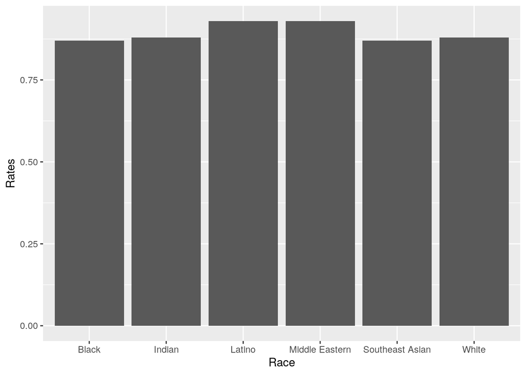

## Results

Even in the case with the largest and most diverse dataset, there is evidence that race plays a role in the accuracy score. If we assume that these rates are typical, then we see that

$$z = \frac{x-u}{\sigma}$$

or

.00025 for the FERET datase, .0441 for the LFW dataset, and .75 for the Fairface set.

If we let $\alpha = .10 \text{ or alpha} = .05$, then we can reject the first null hypothesis. There is sufficient evidence to suggest that accuracy varies by race for many models. Notably, this does not apply to the Fairface data since it was constructed to be diverse, adding further evidence to the claim. Furthermore, this is evidence in favor of the third alternate hypothesis that more diverse data leads to better results.

The second hypothesis hinges on the assumption that the luminance value of an image will correlate strongly with the accuracy value (i.e. that more light leads to better results). By calculating the correlation of the f1-scores and luminance values across our data, we find that there is a weak correlation between luminance and accuracy rates (p-value = $.2 * 10^-16$). However, while that correlation is positive, it is weak, with a confidence interval of .21 to .35.

### Sampling Methods

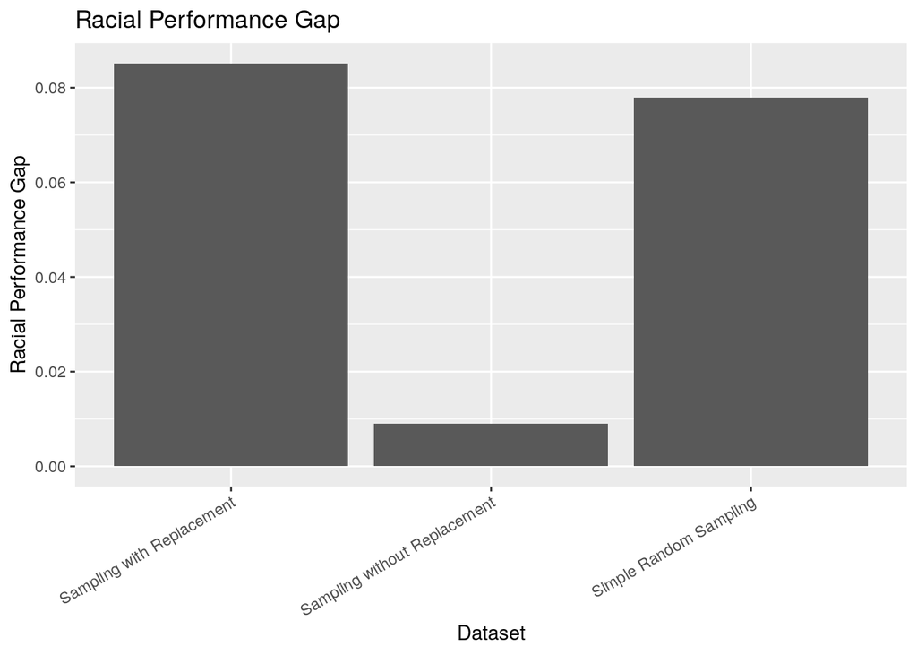

# Conclusion

# Further Work

Further work is needed to thouroughly investigate the causal relationships between sample size, class size, and class variance relative to the mean of the population with respect to racial distribution in both the sample and the population. There was a strict time and cost limitation on the research, but further research would be easy because of the self-contained tooling required for this paper. In particular, a dedicated GPU cluster would help with learning as well as testing hundreds or thousands of different partitions of the training sets. Furthermore, if we controlled for things like gender, perceived race, the presence of facial hair or glasses, and other such topics that vary across sets, then we could develop more confidence that the racial bias we find is due to sample selection alone. However, we are left with weak evidence of how to mititgate the bias that is clearly present when constructing models from certain data sets.

# Sources:

“3.3.9.7. Otsu thresholding — Scipy lecture notes.” 2019. https://scipy-lectures.org/packages/scikit-image/auto_examples/plot_threshold.html.

“Amazon Rekognition Video and Image - AWS.” 2019. *Amazon Web Services, Inc*. https://aws.amazon.com/rekognition.

Barsh, Gregory S. 2003. “What Controls Variation in Human Skin Color?” *PLoS Biol.* 1 (1). Public Library of Science. https://doi.org/10.1371/journal.pbio.0000027.

Bartlett, M S. 2002. “Face Recognition by Independent Component Analysis.” *IEEE Trans. On Neural Networks* 13 (6): 1450–64. http://dx.doi.org/10.1109/TNN.2002.804287.

Del Bino, S., and F. Bernerd. 2013. “Variations in skin colour and the biological consequences of ultraviolet radiation exposure.” *British Journal of Dermatology* 169 (October). John Wiley & Sons, Ltd (10.1111): 33–40. https://doi.org/10.1111/bjd.12529.

Dressel, Julia, and Hany Farid. 2018. “The accuracy, fairness, and limits of predicting recidivism.” *Sci. Adv.* 4 (1). American Association for the Advancement of Science: eaao5580. https://doi.org/10.1126/sciadv.aao5580.

Etemad, Kamran, and Rama Chellappa. 1997. “Discriminant analysis for recognition of human face images.” *SpringerLink*, March. Springer, Berlin, Heidelberg, 125–42. https://doi.org/10.1007/BFb0015988.

Gopalakrishnan, Kasthurirangan, S.K. Khaitan, Alok Choudhary, and Ankit Agrawal. 2017. “Deep Convolutional Neural Networks with Transfer Learning for Computer Vision-Based Data-Driven Pavement Distress Detection.” *Construction and Building Materials* 157 (September): 322–30. https://doi.org/10.1016/j.conbuildmat.2017.09.110.

“ImageNet.” 2019. http://www.image-net.org.

“ImageNet Large Scale Visual Recognition Competition 2014 (ILSVRC2014).” 2019. http://www.image-net.org/challenges/LSVRC/2014/results.

joojs. 2019. “fairface.” *GitHub*. https://github.com/joojs/fairface.

Kimmo, and Jungseock Joo. 2019. “FairFace: Face Attribute Dataset for Balanced Race, Gender, and Age.” *arXiv*, August. https://arxiv.org/abs/1908.04913.

Kummerfeld, Erich, and Alexander Rix. 2019. “Simulations evaluating resampling methods for causal discovery: ensemble performance and calibration.” *arXiv*, October. https://arxiv.org/abs/1910.02047.

“LFW Face Database : Main.” 2019. http://vis-www.cs.umass.edu/lfw.

Liao, Shannon. 2019. “Apple claims it isn’t scanning customers’ faces, after teen sues for $1 billion.” *Verge*, April. The Verge. https://www.theverge.com/tech/2019/4/23/18512942/apple-lawsuit-facial-recognition-nypd-1-billion-theft.

Liu, Shuying, and Weihong Deng. 2015. “Very deep convolutional neural network based image classification using small training sample size.” *2015 3rd IAPR Asian Conference on Pattern Recognition (ACPR)*, November. IEEE, 730–34. https://doi.org/10.1109/ACPR.2015.7486599.

Mahabadi, JAmes, Rabeeh; Henderson. 2019. “Simple but Effective Techniques to Reduce Bias.” 2019. https://arxiv.org/abs/1909.06321.

Mellon, Carnegie. 2019. “openface.” *GitHub*, September. https://github.com/cmusatyalab/openface.

opencv. 2019. “opencv.” *GitHub*. https://github.com/opencv/opencv.

“Report on Algorithmic Risk Assessment Tools in the U.S. Criminal Justice System - The Partnership on AI.” 2019. *Partnership on AI*. https://www.partnershiponai.org/report-on-machine-learning-in-risk-assessment-tools-in-the-u-s-criminal-justice-system.

“RGB to grayscale — skimage v0.17.dev0 docs.” 2019. https://scikit-image.org/docs/dev/auto_examples/color_exposure/plot_rgb_to_gray.html.

Simonyan, Karen, and Andrew Zisserman. 2014. “Very Deep Convolutional Networks for Large-Scale Image Recognition.” *arXiv*, September. https://arxiv.org/abs/1409.1556.

Turk, M. 1991. *Eigenfaces for Recognition*. Vol. 3. Journal of Cognitive Neuroscience.

Turner-Lee, Nicol, Paul Resnick, and Genie Barton. 2019. “Algorithmic bias detection and mitigation: Best practices and policies to reduce consumer harms.” *Brookings*, October. Brookings. https://www.brookings.edu/research/algorithmic-bias-detection-and-mitigation-best-practices-and-policies-to-reduce-consumer-harms.

Viola, P., and M. Jones. 2001. *Rapid object detection using a boosted cascade of simple features*. *Proceedings of the 2001 IEEE Computer Society Conference on Computer Vision and Pattern Recognition. CVPR 2001*. Vol. 1. IEEE. https://doi.org/10.1109/CVPR.2001.990517.

Yong, Ed. 2018. “The Atlantic.” *Atlantic*, January. https://www.theatlantic.com/technology/archive/2018/01/equivant-compas-algorithm/550646.

2019a. *arXiv*. https://arxiv.org/abs/1902.11097.pdf.

2019b. *arXiv*. https://arxiv.org/abs/1908.04913.pdf.